# Risk Factor Analysis

## Outcome Variable

**Outcome Variable:** swasted

## Predictor Variables

**Intervention Variable:** birthwt

**Adjustment Set:**

- arm
- sex
- W_mage
- meducyrs
- feducyrs
- hhwealth_quart
- vagbrth
- W_nrooms
- brthmon
- W_parity
- impfloor
- impsan
- safeh20
- delta_W_mage
- delta_meducyrs
- delta_feducyrs
- delta_hhwealth_quart
- delta_vagbrth
- delta_W_nrooms
- delta_brthmon
- delta_W_parity
- delta_impfloor
- delta_impsan
- delta_safeh20

## Stratifying Variables

The analysis was stratified on these variable(s):

- agecat
- studyid
- country

## Data Summary

| agecat | studyid | country | birthwt | swasted | n_cell | n |
| --- | --- | --- | --- | --- | --- | --- |
| Birth | ki0047075b-MAL-ED | BANGLADESH | Normal or high birthweight | 0 | 197 | 241 |
| Birth | ki0047075b-MAL-ED | BANGLADESH | Normal or high birthweight | 1 | 5 | 241 |
| Birth | ki0047075b-MAL-ED | BANGLADESH | Low birth weight | 0 | 36 | 241 |
| Birth | ki0047075b-MAL-ED | BANGLADESH | Low birth weight | 1 | 3 | 241 |
| Birth | ki0047075b-MAL-ED | BRAZIL | Normal or high birthweight | 0 | 179 | 183 |
| Birth | ki0047075b-MAL-ED | BRAZIL | Normal or high birthweight | 1 | 0 | 183 |
| Birth | ki0047075b-MAL-ED | BRAZIL | Low birth weight | 0 | 4 | 183 |
| Birth | ki0047075b-MAL-ED | BRAZIL | Low birth weight | 1 | 0 | 183 |
| Birth | ki0047075b-MAL-ED | INDIA | Normal or high birthweight | 0 | 168 | 203 |
| Birth | ki0047075b-MAL-ED | INDIA | Normal or high birthweight | 1 | 3 | 203 |
| Birth | ki0047075b-MAL-ED | INDIA | Low birth weight | 0 | 28 | 203 |
| Birth | ki0047075b-MAL-ED | INDIA | Low birth weight | 1 | 4 | 203 |
| Birth | ki0047075b-MAL-ED | NEPAL | Normal or high birthweight | 0 | 152 | 168 |
| Birth | ki0047075b-MAL-ED | NEPAL | Normal or high birthweight | 1 | 3 | 168 |
| Birth | ki0047075b-MAL-ED | NEPAL | Low birth weight | 0 | 12 | 168 |
| Birth | ki0047075b-MAL-ED | NEPAL | Low birth weight | 1 | 1 | 168 |
| Birth | ki0047075b-MAL-ED | PERU | Normal or high birthweight | 0 | 265 | 279 |
| Birth | ki0047075b-MAL-ED | PERU | Normal or high birthweight | 1 | 0 | 279 |
| Birth | ki0047075b-MAL-ED | PERU | Low birth weight | 0 | 14 | 279 |
| Birth | ki0047075b-MAL-ED | PERU | Low birth weight | 1 | 0 | 279 |
| Birth | ki0047075b-MAL-ED | SOUTH AFRICA | Normal or high birthweight | 0 | 242 | 258 |
| Birth | ki0047075b-MAL-ED | SOUTH AFRICA | Normal or high birthweight | 1 | 2 | 258 |
| Birth | ki0047075b-MAL-ED | SOUTH AFRICA | Low birth weight | 0 | 14 | 258 |
| Birth | ki0047075b-MAL-ED | SOUTH AFRICA | Low birth weight | 1 | 0 | 258 |
| Birth | ki0047075b-MAL-ED | TANZANIA, UNITED REPUBLIC OF | Normal or high birthweight | 0 | 112 | 118 |
| Birth | ki0047075b-MAL-ED | TANZANIA, UNITED REPUBLIC OF | Normal or high birthweight | 1 | 1 | 118 |
| Birth | ki0047075b-MAL-ED | TANZANIA, UNITED REPUBLIC OF | Low birth weight | 0 | 5 | 118 |
| Birth | ki0047075b-MAL-ED | TANZANIA, UNITED REPUBLIC OF | Low birth weight | 1 | 0 | 118 |
| Birth | ki1000108-CMC-V-BCS-2002 | INDIA | Normal or high birthweight | 0 | 75 | 88 |
| Birth | ki1000108-CMC-V-BCS-2002 | INDIA | Normal or high birthweight | 1 | 4 | 88 |

[output cut: 286 more lines]

The following strata were considered:

- agecat: 24 months, studyid: ki0047075b-MAL-ED, country: BANGLADESH
- agecat: 24 months, studyid: ki0047075b-MAL-ED, country: BRAZIL
- agecat: 24 months, studyid: ki0047075b-MAL-ED, country: INDIA
- agecat: 24 months, studyid: ki0047075b-MAL-ED, country: NEPAL
- agecat: 24 months, studyid: ki0047075b-MAL-ED, country: PERU
- agecat: 24 months, studyid: ki0047075b-MAL-ED, country: SOUTH AFRICA
- agecat: 24 months, studyid: ki0047075b-MAL-ED, country: TANZANIA, UNITED REPUBLIC OF
- agecat: 24 months, studyid: ki1000108-CMC-V-BCS-2002, country: INDIA
- agecat: 24 months, studyid: ki1000108-IRC, country: INDIA
- agecat: 24 months, studyid: ki1017093-NIH-Birth, country: BANGLADESH
- agecat: 24 months, studyid: ki1017093b-PROVIDE, country: BANGLADESH
- agecat: 24 months, studyid: ki1017093c-NIH-Crypto, country: BANGLADESH
- agecat: 24 months, studyid: ki1066203-TanzaniaChild2, country: TANZANIA, UNITED REPUBLIC OF
- agecat: 24 months, studyid: ki1101329-Keneba, country: GAMBIA
- agecat: 24 months, studyid: ki1114097-CMIN, country: BANGLADESH
- agecat: 24 months, studyid: ki1114097-CMIN, country: PERU
- agecat: 24 months, studyid: ki1114097-CONTENT, country: PERU
- agecat: 24 months, studyid: ki1119695-PROBIT, country: BELARUS
- agecat: 24 months, studyid: ki1126311-ZVITAMBO, country: ZIMBABWE
- agecat: 24 months, studyid: ki1135781-COHORTS, country: GUATEMALA
- agecat: 24 months, studyid: ki1135781-COHORTS, country: INDIA
- agecat: 24 months, studyid: ki1135781-COHORTS, country: PHILIPPINES
- agecat: 24 months, studyid: kiGH5241-JiVitA-3, country: BANGLADESH
- agecat: 24 months, studyid: kiGH5241-JiVitA-4, country: BANGLADESH
- agecat: 6 months, studyid: ki0047075b-MAL-ED, country: BANGLADESH
- agecat: 6 months, studyid: ki0047075b-MAL-ED, country: BRAZIL
- agecat: 6 months, studyid: ki0047075b-MAL-ED, country: INDIA
- agecat: 6 months, studyid: ki0047075b-MAL-ED, country: NEPAL
- agecat: 6 months, studyid: ki0047075b-MAL-ED, country: PERU
- agecat: 6 months, studyid: ki0047075b-MAL-ED, country: SOUTH AFRICA
- agecat: 6 months, studyid: ki0047075b-MAL-ED, country: TANZANIA, UNITED REPUBLIC OF
- agecat: 6 months, studyid: ki1000108-CMC-V-BCS-2002, country: INDIA
- agecat: 6 months, studyid: ki1000108-IRC, country: INDIA
- agecat: 6 months, studyid: ki1000109-EE, country: PAKISTAN
- agecat: 6 months, studyid: ki1000109-ResPak, country: PAKISTAN
- agecat: 6 months, studyid: ki1000304b-SAS-CompFeed, country: INDIA
- agecat: 6 months, studyid: ki1017093-NIH-Birth, country: BANGLADESH
- agecat: 6 months, studyid: ki1017093b-PROVIDE, country: BANGLADESH
- agecat: 6 months, studyid: ki1017093c-NIH-Crypto, country: BANGLADESH
- agecat: 6 months, studyid: ki1066203-TanzaniaChild2, country: TANZANIA, UNITED REPUBLIC OF
- agecat: 6 months, studyid: ki1101329-Keneba, country: GAMBIA
- agecat: 6 months, studyid: ki1114097-CMIN, country: BANGLADESH
- agecat: 6 months, studyid: ki1114097-CMIN, country: BRAZIL
- agecat: 6 months, studyid: ki1114097-CMIN, country: GUINEA-BISSAU
- agecat: 6 months, studyid: ki1114097-CMIN, country: PERU
- agecat: 6 months, studyid: ki1114097-CONTENT, country: PERU
- agecat: 6 months, studyid: ki1119695-PROBIT, country: BELARUS
- agecat: 6 months, studyid: ki1126311-ZVITAMBO, country: ZIMBABWE
- agecat: 6 months, studyid: ki1135781-COHORTS, country: GUATEMALA
- agecat: 6 months, studyid: ki1135781-COHORTS, country: INDIA
- agecat: 6 months, studyid: ki1135781-COHORTS, country: PHILIPPINES
- agecat: 6 months, studyid: kiGH5241-JiVitA-3, country: BANGLADESH
- agecat: 6 months, studyid: kiGH5241-JiVitA-4, country: BANGLADESH
- agecat: Birth, studyid: ki0047075b-MAL-ED, country: BANGLADESH
- agecat: Birth, studyid: ki0047075b-MAL-ED, country: BRAZIL
- agecat: Birth, studyid: ki0047075b-MAL-ED, country: INDIA
- agecat: Birth, studyid: ki0047075b-MAL-ED, country: NEPAL
- agecat: Birth, studyid: ki0047075b-MAL-ED, country: PERU
- agecat: Birth, studyid: ki0047075b-MAL-ED, country: SOUTH AFRICA
- agecat: Birth, studyid: ki0047075b-MAL-ED, country: TANZANIA, UNITED REPUBLIC OF
- agecat: Birth, studyid: ki1000108-CMC-V-BCS-2002, country: INDIA
- agecat: Birth, studyid: ki1000108-IRC, country: INDIA
- agecat: Birth, studyid: ki1000109-EE, country: PAKISTAN
- agecat: Birth, studyid: ki1000109-ResPak, country: PAKISTAN
- agecat: Birth, studyid: ki1000304b-SAS-CompFeed, country: INDIA
- agecat: Birth, studyid: ki1017093-NIH-Birth, country: BANGLADESH
- agecat: Birth, studyid: ki1017093c-NIH-Crypto, country: BANGLADESH
- agecat: Birth, studyid: ki1101329-Keneba, country: GAMBIA
- agecat: Birth, studyid: ki1114097-CMIN, country: BANGLADESH
- agecat: Birth, studyid: ki1114097-CMIN, country: BRAZIL
- agecat: Birth, studyid: ki1114097-CMIN, country: PERU
- agecat: Birth, studyid: ki1114097-CONTENT, country: PERU
- agecat: Birth, studyid: ki1119695-PROBIT, country: BELARUS
- agecat: Birth, studyid: ki1126311-ZVITAMBO, country: ZIMBABWE
- agecat: Birth, studyid: ki1135781-COHORTS, country: GUATEMALA
- agecat: Birth, studyid: ki1135781-COHORTS, country: INDIA
- agecat: Birth, studyid: ki1135781-COHORTS, country: PHILIPPINES
- agecat: Birth, studyid: kiGH5241-JiVitA-3, country: BANGLADESH
- agecat: Birth, studyid: kiGH5241-JiVitA-4, country: BANGLADESH

### Dropped Strata

Some strata were dropped due to rare outcomes:

- agecat: Birth, studyid: ki0047075b-MAL-ED, country: BANGLADESH
- agecat: Birth, studyid: ki0047075b-MAL-ED, country: BRAZIL
- agecat: Birth, studyid: ki0047075b-MAL-ED, country: INDIA
- agecat: Birth, studyid: ki0047075b-MAL-ED, country: NEPAL
- agecat: Birth, studyid: ki0047075b-MAL-ED, country: PERU
- agecat: Birth, studyid: ki0047075b-MAL-ED, country: SOUTH AFRICA
- agecat: Birth, studyid: ki0047075b-MAL-ED, country: TANZANIA, UNITED REPUBLIC OF
- agecat: Birth, studyid: ki1000108-CMC-V-BCS-2002, country: INDIA
- agecat: Birth, studyid: ki1000109-EE, country: PAKISTAN
- agecat: Birth, studyid: ki1000109-ResPak, country: PAKISTAN
- agecat: Birth, studyid: ki1000304b-SAS-CompFeed, country: INDIA
- agecat: Birth, studyid: ki1017093-NIH-Birth, country: BANGLADESH
- agecat: Birth, studyid: ki1017093c-NIH-Crypto, country: BANGLADESH
- agecat: Birth, studyid: ki1114097-CMIN, country: BANGLADESH
- agecat: Birth, studyid: ki1114097-CMIN, country: BRAZIL
- agecat: Birth, studyid: ki1114097-CMIN, country: PERU
- agecat: Birth, studyid: ki1114097-CONTENT, country: PERU
- agecat: Birth, studyid: ki1119695-PROBIT, country: BELARUS
- agecat: Birth, studyid: kiGH5241-JiVitA-4, country: BANGLADESH
- agecat: 6 months, studyid: ki0047075b-MAL-ED, country: BANGLADESH
- agecat: 6 months, studyid: ki0047075b-MAL-ED, country: BRAZIL
- agecat: 6 months, studyid: ki0047075b-MAL-ED, country: INDIA
- agecat: 6 months, studyid: ki0047075b-MAL-ED, country: NEPAL
- agecat: 6 months, studyid: ki0047075b-MAL-ED, country: PERU
- agecat: 6 months, studyid: ki0047075b-MAL-ED, country: SOUTH AFRICA
- agecat: 6 months, studyid: ki0047075b-MAL-ED, country: TANZANIA, UNITED REPUBLIC OF
- agecat: 6 months, studyid: ki1000108-CMC-V-BCS-2002, country: INDIA
- agecat: 6 months, studyid: ki1000109-ResPak, country: PAKISTAN
- agecat: 6 months, studyid: ki1017093-NIH-Birth, country: BANGLADESH
- agecat: 6 months, studyid: ki1017093b-PROVIDE, country: BANGLADESH
- agecat: 6 months, studyid: ki1017093c-NIH-Crypto, country: BANGLADESH
- agecat: 6 months, studyid: ki1066203-TanzaniaChild2, country: TANZANIA, UNITED REPUBLIC OF
- agecat: 6 months, studyid: ki1101329-Keneba, country: GAMBIA
- agecat: 6 months, studyid: ki1114097-CMIN, country: BANGLADESH
- agecat: 6 months, studyid: ki1114097-CMIN, country: BRAZIL
- agecat: 6 months, studyid: ki1114097-CMIN, country: GUINEA-BISSAU
- agecat: 6 months, studyid: ki1114097-CMIN, country: PERU
- agecat: 6 months, studyid: ki1114097-CONTENT, country: PERU
- agecat: 6 months, studyid: ki1119695-PROBIT, country: BELARUS
- agecat: 6 months, studyid: ki1135781-COHORTS, country: GUATEMALA
- agecat: 24 months, studyid: ki0047075b-MAL-ED, country: BANGLADESH
- agecat: 24 months, studyid: ki0047075b-MAL-ED, country: BRAZIL
- agecat: 24 months, studyid: ki0047075b-MAL-ED, country: INDIA
- agecat: 24 months, studyid: ki0047075b-MAL-ED, country: NEPAL
- agecat: 24 months, studyid: ki0047075b-MAL-ED, country: PERU
- agecat: 24 months, studyid: ki0047075b-MAL-ED, country: SOUTH AFRICA
- agecat: 24 months, studyid: ki0047075b-MAL-ED, country: TANZANIA, UNITED REPUBLIC OF
- agecat: 24 months, studyid: ki1000108-CMC-V-BCS-2002, country: INDIA
- agecat: 24 months, studyid: ki1000108-IRC, country: INDIA
- agecat: 24 months, studyid: ki1017093-NIH-Birth, country: BANGLADESH
- agecat: 24 months, studyid: ki1017093b-PROVIDE, country: BANGLADESH
- agecat: 24 months, studyid: ki1017093c-NIH-Crypto, country: BANGLADESH
- agecat: 24 months, studyid: ki1066203-TanzaniaChild2, country: TANZANIA, UNITED REPUBLIC OF
- agecat: 24 months, studyid: ki1101329-Keneba, country: GAMBIA
- agecat: 24 months, studyid: ki1114097-CMIN, country: BANGLADESH
- agecat: 24 months, studyid: ki1114097-CMIN, country: PERU
- agecat: 24 months, studyid: ki1114097-CONTENT, country: PERU
- agecat: 24 months, studyid: ki1119695-PROBIT, country: BELARUS
- agecat: 24 months, studyid: ki1135781-COHORTS, country: GUATEMALA
- agecat: 24 months, studyid: ki1135781-COHORTS, country: PHILIPPINES

## Methods Detail

We’re interested in the causal parameters $E[Y_a]$ for all values of $a \in \mathcal{A}$. These parameters represent the mean outcome if, possibly contrary to fact, we intervened to set all units to have $A=a$. Under the randomization and positivity assumptions, these are identified by the statistical parameters $\psi_a=E_W[E_{Y|A,W}(Y|A=a,W)]$. In addition, we’re interested in the mean of $Y$, $E[Y]$ under no intervention (the observed mean). We will estimate these parameters by using SuperLearner to fit the relevant likelihood factors – $E_{Y|A,W}(Y|A=a,W)$ and $p(A=a|W)$, and then updating our likelihood fit using a joint TMLE.

For unadjusted analyses ($W=\{\}$), initial likelihoods were estimated using Lrnr_glm to estimate the simple $E(Y|A)$ and Lrnr_mean to estimate $p(A)$. For adjusted analyses, a small library containing Lrnr_glmnet, Lrnr_xgboost, and Lrnr_mean was used.

Having estimated these parameters, we will then use the delta method to estimate relative risks and attributable risks relative to a prespecified baseline level of $A$.

# Results Detail

## Results Plots

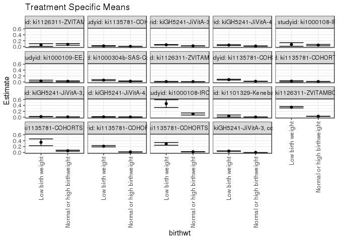

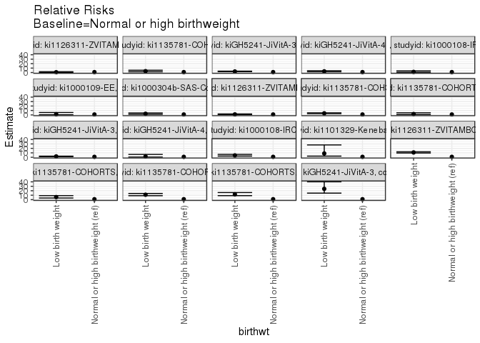

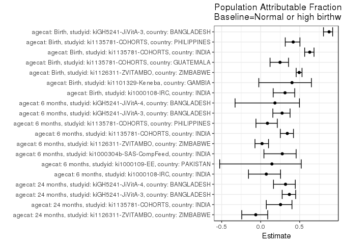

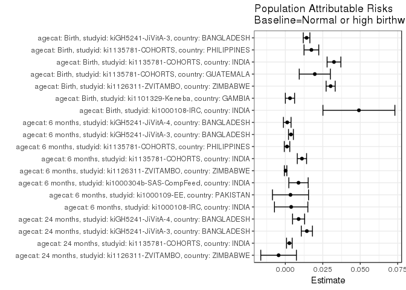

## Results Table

### Parameter: TSM

| agecat | studyid | country | intervention_level | baseline_level | estimate | ci_lower | ci_upper |
| --- | --- | --- | --- | --- | --- | --- | --- |
| Birth | ki1000108-IRC | INDIA | Normal or high birthweight | NA | 0.1083219 | 0.0729796 | 0.1436643 |
| Birth | ki1000108-IRC | INDIA | Low birth weight | NA | 0.4600746 | 0.3279982 | 0.5921510 |
| Birth | ki1101329-Keneba | GAMBIA | Normal or high birthweight | NA | 0.0046261 | 0.0009318 | 0.0083203 |
| Birth | ki1101329-Keneba | GAMBIA | Low birth weight | NA | 0.0396825 | 0.0055850 | 0.0737800 |
| Birth | ki1126311-ZVITAMBO | ZIMBABWE | Normal or high birthweight | NA | 0.0310028 | 0.0278544 | 0.0341511 |
| Birth | ki1126311-ZVITAMBO | ZIMBABWE | Low birth weight | NA | 0.3371188 | 0.3128073 | 0.3614303 |
| Birth | ki1135781-COHORTS | GUATEMALA | Normal or high birthweight | NA | 0.0596981 | 0.0421719 | 0.0772243 |
| Birth | ki1135781-COHORTS | GUATEMALA | Low birth weight | NA | 0.3450447 | 0.2296324 | 0.4604569 |
| Birth | ki1135781-COHORTS | INDIA | Normal or high birthweight | NA | 0.0191995 | 0.0154579 | 0.0229411 |
| Birth | ki1135781-COHORTS | INDIA | Low birth weight | NA | 0.2136743 | 0.1898634 | 0.2374852 |
| Birth | ki1135781-COHORTS | PHILIPPINES | Normal or high birthweight | NA | 0.0243458 | 0.0185189 | 0.0301727 |
| Birth | ki1135781-COHORTS | PHILIPPINES | Low birth weight | NA | 0.2921178 | 0.2448054 | 0.3394303 |
| Birth | kiGH5241-JiVitA-3 | BANGLADESH | Normal or high birthweight | NA | 0.0019919 | 0.0010110 | 0.0029727 |
| Birth | kiGH5241-JiVitA-3 | BANGLADESH | Low birth weight | NA | 0.0482861 | 0.0413204 | 0.0552517 |
| 6 months | ki1000108-IRC | INDIA | Normal or high birthweight | NA | 0.0502959 | 0.0269674 | 0.0736243 |
| 6 months | ki1000108-IRC | INDIA | Low birth weight | NA | 0.0735294 | 0.0114174 | 0.1356414 |
| 6 months | ki1000109-EE | PAKISTAN | Normal or high birthweight | NA | 0.0204918 | 0.0026916 | 0.0382920 |
| 6 months | ki1000109-EE | PAKISTAN | Low birth weight | NA | 0.0303030 | 0.0010210 | 0.0595850 |
| 6 months | ki1000304b-SAS-CompFeed | INDIA | Normal or high birthweight | NA | 0.0229406 | 0.0135788 | 0.0323024 |
| 6 months | ki1000304b-SAS-CompFeed | INDIA | Low birth weight | NA | 0.0600506 | 0.0419172 | 0.0781839 |
| 6 months | ki1126311-ZVITAMBO | ZIMBABWE | Normal or high birthweight | NA | 0.0094262 | 0.0071951 | 0.0116574 |
| 6 months | ki1126311-ZVITAMBO | ZIMBABWE | Low birth weight | NA | 0.0110549 | 0.0047586 | 0.0173511 |
| 6 months | ki1135781-COHORTS | INDIA | Normal or high birthweight | NA | 0.0213876 | 0.0173944 | 0.0253807 |
| 6 months | ki1135781-COHORTS | INDIA | Low birth weight | NA | 0.0770634 | 0.0629235 | 0.0912032 |
| 6 months | ki1135781-COHORTS | PHILIPPINES | Normal or high birthweight | NA | 0.0120033 | 0.0076601 | 0.0163465 |
| 6 months | ki1135781-COHORTS | PHILIPPINES | Low birth weight | NA | 0.0241935 | 0.0050671 | 0.0433200 |
| 6 months | kiGH5241-JiVitA-3 | BANGLADESH | Normal or high birthweight | NA | 0.0098970 | 0.0078030 | 0.0119910 |
| 6 months | kiGH5241-JiVitA-3 | BANGLADESH | Low birth weight | NA | 0.0194641 | 0.0154576 | 0.0234705 |
| 6 months | kiGH5241-JiVitA-4 | BANGLADESH | Normal or high birthweight | NA | 0.0056619 | 0.0002798 | 0.0110441 |
| 6 months | kiGH5241-JiVitA-4 | BANGLADESH | Low birth weight | NA | 0.0105820 | 0.0023161 | 0.0188480 |
| 24 months | ki1126311-ZVITAMBO | ZIMBABWE | Normal or high birthweight | NA | 0.0757576 | 0.0471742 | 0.1043410 |
| 24 months | ki1126311-ZVITAMBO | ZIMBABWE | Low birth weight | NA | 0.0549451 | 0.0080706 | 0.1018196 |
| 24 months | ki1135781-COHORTS | INDIA | Normal or high birthweight | NA | 0.0078875 | 0.0051273 | 0.0106478 |
| 24 months | ki1135781-COHORTS | INDIA | Low birth weight | NA | 0.0245226 | 0.0147973 | 0.0342479 |
| 24 months | kiGH5241-JiVitA-3 | BANGLADESH | Normal or high birthweight | NA | 0.0246881 | 0.0203412 | 0.0290351 |
| 24 months | kiGH5241-JiVitA-3 | BANGLADESH | Low birth weight | NA | 0.0610155 | 0.0524739 | 0.0695571 |
| 24 months | kiGH5241-JiVitA-4 | BANGLADESH | Normal or high birthweight | NA | 0.0189472 | 0.0129865 | 0.0249078 |
| 24 months | kiGH5241-JiVitA-4 | BANGLADESH | Low birth weight | NA | 0.0521604 | 0.0379056 | 0.0664152 |

### Parameter: E(Y)

| agecat | studyid | country | intervention_level | baseline_level | estimate | ci_lower | ci_upper |
| --- | --- | --- | --- | --- | --- | --- | --- |
| Birth | ki1000108-IRC | INDIA | NA | NA | 0.1574344 | 0.1188345 | 0.1960344 |
| Birth | ki1101329-Keneba | GAMBIA | NA | NA | 0.0077301 | 0.0031781 | 0.0122822 |
| Birth | ki1126311-ZVITAMBO | ZIMBABWE | NA | NA | 0.0612419 | 0.0571066 | 0.0653771 |
| Birth | ki1135781-COHORTS | GUATEMALA | NA | NA | 0.0793651 | 0.0600839 | 0.0986462 |
| Birth | ki1135781-COHORTS | INDIA | NA | NA | 0.0516712 | 0.0461576 | 0.0571849 |
| Birth | ki1135781-COHORTS | PHILIPPINES | NA | NA | 0.0417385 | 0.0344572 | 0.0490198 |
| Birth | kiGH5241-JiVitA-3 | BANGLADESH | NA | NA | 0.0161691 | 0.0138058 | 0.0185324 |
| 6 months | ki1000108-IRC | INDIA | NA | NA | 0.0541872 | 0.0321391 | 0.0762353 |
| 6 months | ki1000109-EE | PAKISTAN | NA | NA | 0.0239362 | 0.0084659 | 0.0394065 |
| 6 months | ki1000304b-SAS-CompFeed | INDIA | NA | NA | 0.0317221 | 0.0237601 | 0.0396840 |
| 6 months | ki1126311-ZVITAMBO | ZIMBABWE | NA | NA | 0.0095944 | 0.0074887 | 0.0117000 |
| 6 months | ki1135781-COHORTS | INDIA | NA | NA | 0.0324696 | 0.0280758 | 0.0368634 |
| 6 months | ki1135781-COHORTS | PHILIPPINES | NA | NA | 0.0131381 | 0.0088134 | 0.0174629 |
| 6 months | kiGH5241-JiVitA-3 | BANGLADESH | NA | NA | 0.0136437 | 0.0115506 | 0.0157368 |
| 6 months | kiGH5241-JiVitA-4 | BANGLADESH | NA | NA | 0.0069273 | 0.0024198 | 0.0114348 |
| 24 months | ki1126311-ZVITAMBO | ZIMBABWE | NA | NA | 0.0712589 | 0.0466558 | 0.0958620 |
| 24 months | ki1135781-COHORTS | INDIA | NA | NA | 0.0105787 | 0.0076905 | 0.0134669 |
| 24 months | kiGH5241-JiVitA-3 | BANGLADESH | NA | NA | 0.0390529 | 0.0347092 | 0.0433966 |
| 24 months | kiGH5241-JiVitA-4 | BANGLADESH | NA | NA | 0.0277917 | 0.0219289 | 0.0336545 |

### Parameter: RR

| agecat | studyid | country | intervention_level | baseline_level | estimate | ci_lower | ci_upper |
| --- | --- | --- | --- | --- | --- | --- | --- |
| Birth | ki1000108-IRC | INDIA | Normal or high birthweight | Normal or high birthweight | 1.0000000 | 1.0000000 | 1.000000 |
| Birth | ki1000108-IRC | INDIA | Low birth weight | Normal or high birthweight | 4.2472901 | 2.7499548 | 6.559916 |
| Birth | ki1101329-Keneba | GAMBIA | Normal or high birthweight | Normal or high birthweight | 1.0000000 | 1.0000000 | 1.000000 |
| Birth | ki1101329-Keneba | GAMBIA | Low birth weight | Normal or high birthweight | 8.5780423 | 2.6542262 | 27.722886 |
| Birth | ki1126311-ZVITAMBO | ZIMBABWE | Normal or high birthweight | Normal or high birthweight | 1.0000000 | 1.0000000 | 1.000000 |
| Birth | ki1126311-ZVITAMBO | ZIMBABWE | Low birth weight | Normal or high birthweight | 10.8738284 | 9.6007580 | 12.315709 |
| Birth | ki1135781-COHORTS | GUATEMALA | Normal or high birthweight | Normal or high birthweight | 1.0000000 | 1.0000000 | 1.000000 |
| Birth | ki1135781-COHORTS | GUATEMALA | Low birth weight | Normal or high birthweight | 5.7798239 | 3.7042974 | 9.018273 |
| Birth | ki1135781-COHORTS | INDIA | Normal or high birthweight | Normal or high birthweight | 1.0000000 | 1.0000000 | 1.000000 |
| Birth | ki1135781-COHORTS | INDIA | Low birth weight | Normal or high birthweight | 11.1291533 | 8.8924637 | 13.928429 |
| Birth | ki1135781-COHORTS | PHILIPPINES | Normal or high birthweight | Normal or high birthweight | 1.0000000 | 1.0000000 | 1.000000 |
| Birth | ki1135781-COHORTS | PHILIPPINES | Low birth weight | Normal or high birthweight | 11.9986987 | 8.9905554 | 16.013334 |
| Birth | kiGH5241-JiVitA-3 | BANGLADESH | Normal or high birthweight | Normal or high birthweight | 1.0000000 | 1.0000000 | 1.000000 |
| Birth | kiGH5241-JiVitA-3 | BANGLADESH | Low birth weight | Normal or high birthweight | 24.2415048 | 14.6588150 | 40.088544 |
| 6 months | ki1000108-IRC | INDIA | Normal or high birthweight | Normal or high birthweight | 1.0000000 | 1.0000000 | 1.000000 |
| 6 months | ki1000108-IRC | INDIA | Low birth weight | Normal or high birthweight | 1.4619377 | 0.5577062 | 3.832236 |
| 6 months | ki1000109-EE | PAKISTAN | Normal or high birthweight | Normal or high birthweight | 1.0000000 | 1.0000000 | 1.000000 |
| 6 months | ki1000109-EE | PAKISTAN | Low birth weight | Normal or high birthweight | 1.4787879 | 0.4032802 | 5.422566 |
| 6 months | ki1000304b-SAS-CompFeed | INDIA | Normal or high birthweight | Normal or high birthweight | 1.0000000 | 1.0000000 | 1.000000 |
| 6 months | ki1000304b-SAS-CompFeed | INDIA | Low birth weight | Normal or high birthweight | 2.6176544 | 1.5383365 | 4.454237 |
| 6 months | ki1126311-ZVITAMBO | ZIMBABWE | Normal or high birthweight | Normal or high birthweight | 1.0000000 | 1.0000000 | 1.000000 |
| 6 months | ki1126311-ZVITAMBO | ZIMBABWE | Low birth weight | Normal or high birthweight | 1.1727779 | 0.6330578 | 2.172642 |
| 6 months | ki1135781-COHORTS | INDIA | Normal or high birthweight | Normal or high birthweight | 1.0000000 | 1.0000000 | 1.000000 |
| 6 months | ki1135781-COHORTS | INDIA | Low birth weight | Normal or high birthweight | 3.6031835 | 2.7740902 | 4.680068 |
| 6 months | ki1135781-COHORTS | PHILIPPINES | Normal or high birthweight | Normal or high birthweight | 1.0000000 | 1.0000000 | 1.000000 |
| 6 months | ki1135781-COHORTS | PHILIPPINES | Low birth weight | Normal or high birthweight | 2.0155729 | 0.8449075 | 4.808259 |
| 6 months | kiGH5241-JiVitA-3 | BANGLADESH | Normal or high birthweight | Normal or high birthweight | 1.0000000 | 1.0000000 | 1.000000 |
| 6 months | kiGH5241-JiVitA-3 | BANGLADESH | Low birth weight | Normal or high birthweight | 1.9666600 | 1.4795836 | 2.614081 |
| 6 months | kiGH5241-JiVitA-4 | BANGLADESH | Normal or high birthweight | Normal or high birthweight | 1.0000000 | 1.0000000 | 1.000000 |
| 6 months | kiGH5241-JiVitA-4 | BANGLADESH | Low birth weight | Normal or high birthweight | 1.8689698 | 0.5434810 | 6.427176 |
| 24 months | ki1126311-ZVITAMBO | ZIMBABWE | Normal or high birthweight | Normal or high birthweight | 1.0000000 | 1.0000000 | 1.000000 |
| 24 months | ki1126311-ZVITAMBO | ZIMBABWE | Low birth weight | Normal or high birthweight | 0.7252747 | 0.2853526 | 1.843416 |
| 24 months | ki1135781-COHORTS | INDIA | Normal or high birthweight | Normal or high birthweight | 1.0000000 | 1.0000000 | 1.000000 |
| 24 months | ki1135781-COHORTS | INDIA | Low birth weight | Normal or high birthweight | 3.1090279 | 1.8322588 | 5.275485 |
| 24 months | kiGH5241-JiVitA-3 | BANGLADESH | Normal or high birthweight | Normal or high birthweight | 1.0000000 | 1.0000000 | 1.000000 |
| 24 months | kiGH5241-JiVitA-3 | BANGLADESH | Low birth weight | Normal or high birthweight | 2.4714521 | 1.9724735 | 3.096658 |
| 24 months | kiGH5241-JiVitA-4 | BANGLADESH | Normal or high birthweight | Normal or high birthweight | 1.0000000 | 1.0000000 | 1.000000 |
| 24 months | kiGH5241-JiVitA-4 | BANGLADESH | Low birth weight | Normal or high birthweight | 2.7529380 | 1.8257656 | 4.150953 |

### Parameter: PAR

| agecat | studyid | country | intervention_level | baseline_level | estimate | ci_lower | ci_upper |
| --- | --- | --- | --- | --- | --- | --- | --- |
| Birth | ki1000108-IRC | INDIA | Normal or high birthweight | NA | 0.0491125 | 0.0251028 | 0.0731222 |
| Birth | ki1101329-Keneba | GAMBIA | Normal or high birthweight | NA | 0.0031041 | 0.0000234 | 0.0061847 |
| Birth | ki1126311-ZVITAMBO | ZIMBABWE | Normal or high birthweight | NA | 0.0302391 | 0.0272124 | 0.0332658 |
| Birth | ki1135781-COHORTS | GUATEMALA | Normal or high birthweight | NA | 0.0196670 | 0.0092865 | 0.0300474 |
| Birth | ki1135781-COHORTS | INDIA | Normal or high birthweight | NA | 0.0324717 | 0.0278827 | 0.0370608 |
| Birth | ki1135781-COHORTS | PHILIPPINES | Normal or high birthweight | NA | 0.0173927 | 0.0124814 | 0.0223041 |
| Birth | kiGH5241-JiVitA-3 | BANGLADESH | Normal or high birthweight | NA | 0.0141772 | 0.0119707 | 0.0163837 |
| 6 months | ki1000108-IRC | INDIA | Normal or high birthweight | NA | 0.0038913 | -0.0072533 | 0.0150360 |
| 6 months | ki1000109-EE | PAKISTAN | Normal or high birthweight | NA | 0.0034444 | -0.0085952 | 0.0154839 |
| 6 months | ki1000304b-SAS-CompFeed | INDIA | Normal or high birthweight | NA | 0.0087814 | 0.0023171 | 0.0152458 |
| 6 months | ki1126311-ZVITAMBO | ZIMBABWE | Normal or high birthweight | NA | 0.0001681 | -0.0006639 | 0.0010002 |
| 6 months | ki1135781-COHORTS | INDIA | Normal or high birthweight | NA | 0.0110820 | 0.0079778 | 0.0141863 |
| 6 months | ki1135781-COHORTS | PHILIPPINES | Normal or high birthweight | NA | 0.0011348 | -0.0006960 | 0.0029656 |
| 6 months | kiGH5241-JiVitA-3 | BANGLADESH | Normal or high birthweight | NA | 0.0037467 | 0.0021200 | 0.0053734 |
| 6 months | kiGH5241-JiVitA-4 | BANGLADESH | Normal or high birthweight | NA | 0.0012653 | -0.0012815 | 0.0038122 |
| 24 months | ki1126311-ZVITAMBO | ZIMBABWE | Normal or high birthweight | NA | -0.0044987 | -0.0163941 | 0.0073968 |
| 24 months | ki1135781-COHORTS | INDIA | Normal or high birthweight | NA | 0.0026912 | 0.0008169 | 0.0045654 |
| 24 months | kiGH5241-JiVitA-3 | BANGLADESH | Normal or high birthweight | NA | 0.0143648 | 0.0106428 | 0.0180868 |
| 24 months | kiGH5241-JiVitA-4 | BANGLADESH | Normal or high birthweight | NA | 0.0088445 | 0.0048180 | 0.0128710 |

### Parameter: PAF

| agecat | studyid | country | intervention_level | baseline_level | estimate | ci_lower | ci_upper |
| --- | --- | --- | --- | --- | --- | --- | --- |
| Birth | ki1000108-IRC | INDIA | Normal or high birthweight | NA | 0.3119552 | 0.1601326 | 0.4363329 |
| Birth | ki1101329-Keneba | GAMBIA | Normal or high birthweight | NA | 0.4015560 | -0.0242612 | 0.6503478 |
| Birth | ki1126311-ZVITAMBO | ZIMBABWE | Normal or high birthweight | NA | 0.4937652 | 0.4549056 | 0.5298545 |
| Birth | ki1135781-COHORTS | GUATEMALA | Normal or high birthweight | NA | 0.2478036 | 0.1199120 | 0.3571104 |
| Birth | ki1135781-COHORTS | INDIA | Normal or high birthweight | NA | 0.6284295 | 0.5636352 | 0.6836026 |
| Birth | ki1135781-COHORTS | PHILIPPINES | Normal or high birthweight | NA | 0.4167070 | 0.3149298 | 0.5033636 |
| Birth | kiGH5241-JiVitA-3 | BANGLADESH | Normal or high birthweight | NA | 0.8768095 | 0.8048330 | 0.9222415 |
| 6 months | ki1000108-IRC | INDIA | Normal or high birthweight | NA | 0.0718128 | -0.1560997 | 0.2547948 |
| 6 months | ki1000109-EE | PAKISTAN | Normal or high birthweight | NA | 0.1438980 | -0.5257116 | 0.5196270 |
| 6 months | ki1000304b-SAS-CompFeed | INDIA | Normal or high birthweight | NA | 0.2768246 | 0.0414235 | 0.4544174 |
| 6 months | ki1126311-ZVITAMBO | ZIMBABWE | Normal or high birthweight | NA | 0.0175244 | -0.0730531 | 0.1004562 |
| 6 months | ki1135781-COHORTS | INDIA | Normal or high birthweight | NA | 0.3413048 | 0.2516463 | 0.4202216 |
| 6 months | ki1135781-COHORTS | PHILIPPINES | Normal or high birthweight | NA | 0.0863765 | -0.0608389 | 0.2131625 |
| 6 months | kiGH5241-JiVitA-3 | BANGLADESH | Normal or high birthweight | NA | 0.2746099 | 0.1558756 | 0.3766431 |
| 6 months | kiGH5241-JiVitA-4 | BANGLADESH | Normal or high birthweight | NA | 0.1826573 | -0.3283071 | 0.4970673 |
| 24 months | ki1126311-ZVITAMBO | ZIMBABWE | Normal or high birthweight | NA | -0.0631313 | -0.2424857 | 0.0903331 |
| 24 months | ki1135781-COHORTS | INDIA | Normal or high birthweight | NA | 0.2543953 | 0.0721431 | 0.4008490 |
| 24 months | kiGH5241-JiVitA-3 | BANGLADESH | Normal or high birthweight | NA | 0.3678291 | 0.2755266 | 0.4483716 |
| 24 months | kiGH5241-JiVitA-4 | BANGLADESH | Normal or high birthweight | NA | 0.3182431 | 0.1641764 | 0.4439107 |